# Data Visualization with ggplot2

- Show All Code
- Hide All Code
- View Source

Key plot types, principles of good design, and how to spot bad ones

Author

Richard

Published

September 7, 2026

## 0.2 Setup

```r
library(dplyr); library(forcats); library(tibble)
library(ggplot2)
library(plotly)      # interactive plots
library(ggthemes)    # extra themes (theme_economist, etc.)
library(patchwork)   # arrange multiple ggplots side by side

Data <- mtcars
glimpse(Data)
```

```
Rows: 32
Columns: 11
$ mpg  <dbl> 21.0, 21.0, 22.8, 21.4, 18.7, 18.1, 14.3, 24.4, 22.8, 19.2, 17.8,~
$ cyl  <dbl> 6, 6, 4, 6, 8, 6, 8, 4, 4, 6, 6, 8, 8, 8, 8, 8, 8, 4, 4, 4, 4, 8,~
$ disp <dbl> 160.0, 160.0, 108.0, 258.0, 360.0, 225.0, 360.0, 146.7, 140.8, 16~
$ hp   <dbl> 110, 110, 93, 110, 175, 105, 245, 62, 95, 123, 123, 180, 180, 180~
$ drat <dbl> 3.90, 3.90, 3.85, 3.08, 3.15, 2.76, 3.21, 3.69, 3.92, 3.92, 3.92,~
$ wt   <dbl> 2.620, 2.875, 2.320, 3.215, 3.440, 3.460, 3.570, 3.190, 3.150, 3.~
$ qsec <dbl> 16.46, 17.02, 18.61, 19.44, 17.02, 20.22, 15.84, 20.00, 22.90, 18~
$ vs   <dbl> 0, 0, 1, 1, 0, 1, 0, 1, 1, 1, 1, 0, 0, 0, 0, 0, 0, 1, 1, 1, 1, 0,~
$ am   <dbl> 1, 1, 1, 0, 0, 0, 0, 0, 0, 0, 0, 0, 0, 0, 0, 0, 0, 1, 1, 1, 0, 0,~
$ gear <dbl> 4, 4, 4, 3, 3, 3, 3, 4, 4, 4, 4, 3, 3, 3, 3, 3, 3, 4, 4, 4, 3, 3,~
$ carb <dbl> 4, 4, 1, 1, 2, 1, 4, 2, 2, 4, 4, 3, 3, 3, 4, 4, 4, 1, 2, 1, 1, 2,~
```

We’ll use the built-in `mtcars` dataset throughout: one row per car, with both categorical variables (`cyl` = number of cylinders, `am` = transmission type) and numeric variables (`mpg` = miles per gallon, `hp` = horsepower).

The core idea behind `ggplot2` — the **grammar of graphics** — is that every plot is built from the same pieces:

```r
ggplot(data, aes(x = ..., y = ...)) + geom_*() + <scales/labels/theme>
```

You pick a `geom_*` based on **what kind of variable(s) you’re plotting**. That’s the organizing idea for the rest of this lecture.

# 1 Categorical variables: bar plots

Use a bar plot when you want to compare **counts or totals across groups**.

```r
Data %>% count(cyl)
```

```
  cyl  n
1   4 11
2   6  7
3   8 14
```

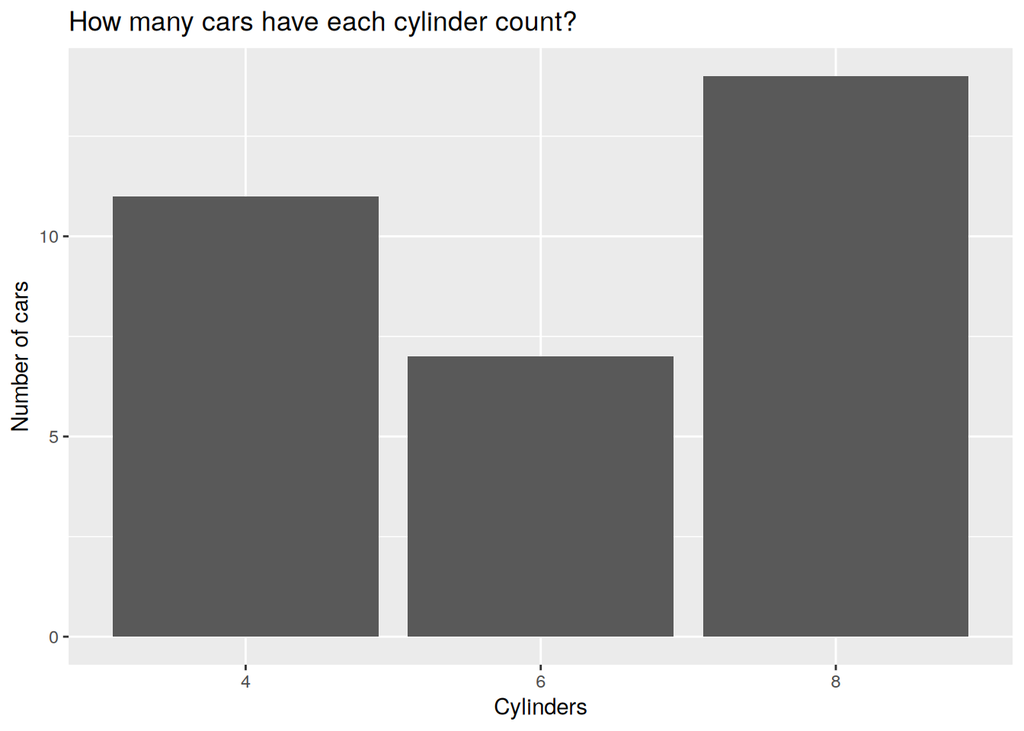

```r
Data %>%
  count(cyl) %>%
  ggplot(aes(x = factor(cyl), y = n)) +
  geom_col() +
  labs(x = "Cylinders", y = "Number of cars",
       title = "How many cars have each cylinder count?")
```

**Note**

`geom_bar(stat = "identity")` and `geom_col()` do the same thing — `geom_col()` is just the shorter, more explicit way to say “the bar height is already my value, don’t count rows for me.”

Save it as an object so we can keep building on it later:

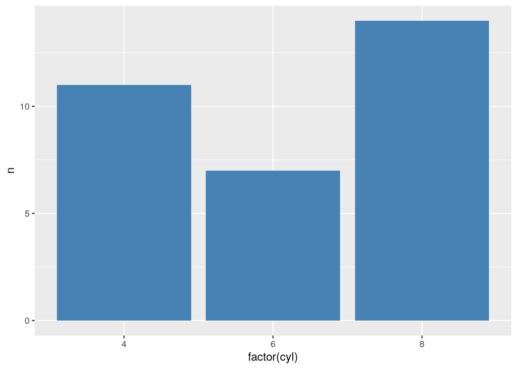

```r
f2 <- Data %>%
  count(cyl) %>%
  ggplot(aes(x = factor(cyl), y = n)) +
  geom_col(fill = "steelblue")
f2
```

## 1.1 Ordering bars meaningfully

Bars in an arbitrary order (e.g. alphabetical) force the reader to hunt for patterns. Order by value instead, unless there’s a natural order (like years):

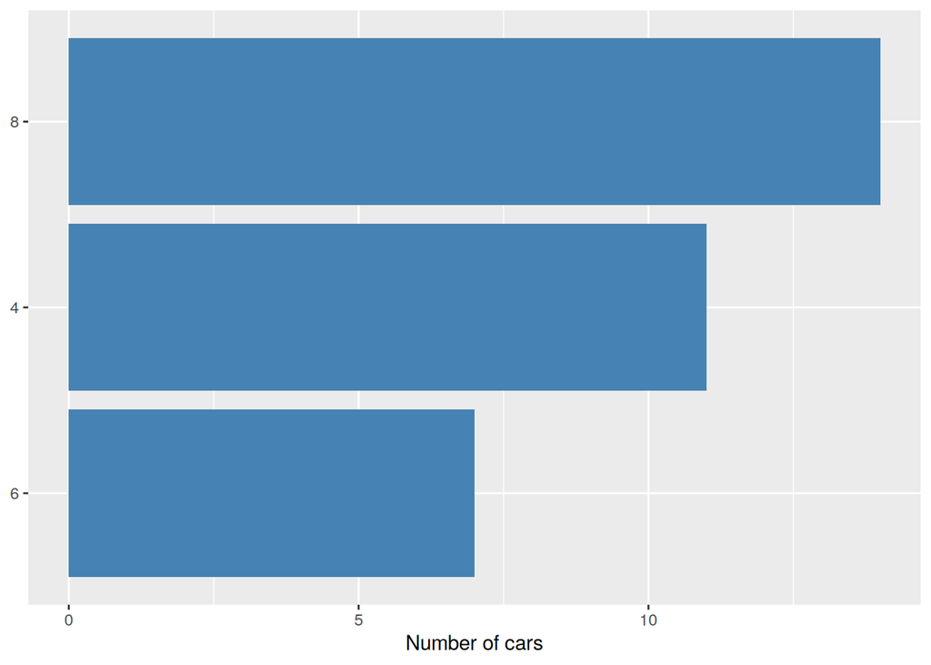

```r
Data %>%
  count(cyl) %>%
  mutate(cyl = fct_reorder(factor(cyl), n)) %>%
  ggplot(aes(x = cyl, y = n)) +
  geom_col(fill = "steelblue") +
  coord_flip() +
  labs(x = NULL, y = "Number of cars")
```

## 1.2 Grouped bars

To compare a *second* categorical variable within each group, use `fill` + `position = "dodge"`:

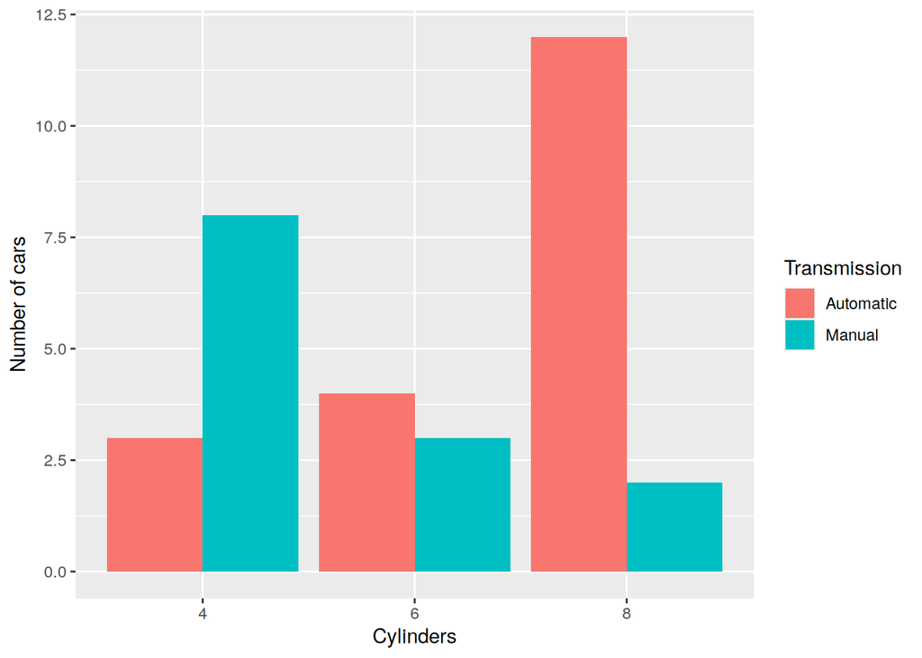

```r
Data %>%
  count(cyl, am) %>%
  mutate(am = factor(am, labels = c("Automatic", "Manual"))) %>%
  ggplot(aes(x = factor(cyl), y = n, fill = am)) +
  geom_col(position = "dodge") +
  labs(x = "Cylinders", y = "Number of cars", fill = "Transmission")
```

**Common mistake**

Don’t use a bar chart for a **continuous numeric** variable without binning it first (e.g., “average mpg per car” with one bar per car). That’s a histogram problem in disguise — see the next section.

# 2 Numeric variables: histograms & density

Use a histogram (or density plot) to see the **distribution** of a single numeric variable: where most values sit, how spread out they are, whether there are outliers.

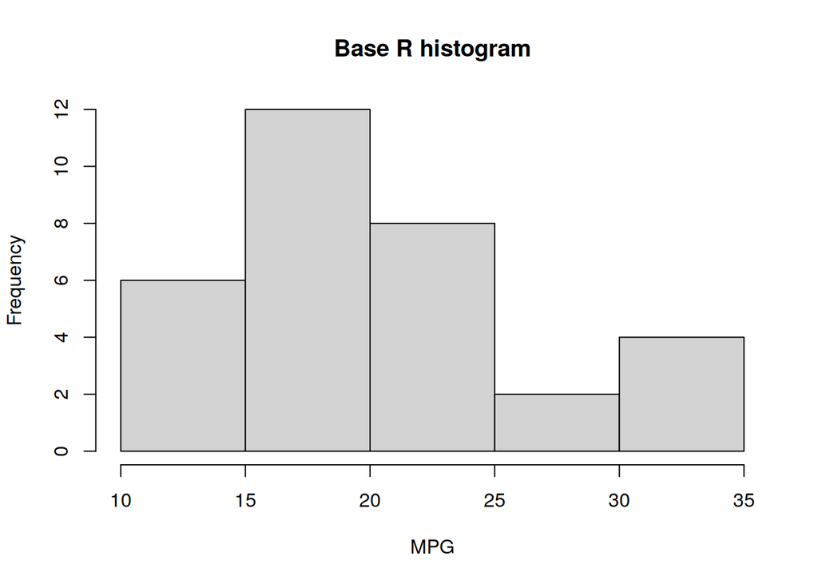

```r
hist(Data$mpg, main = "Base R histogram", xlab = "MPG")
```

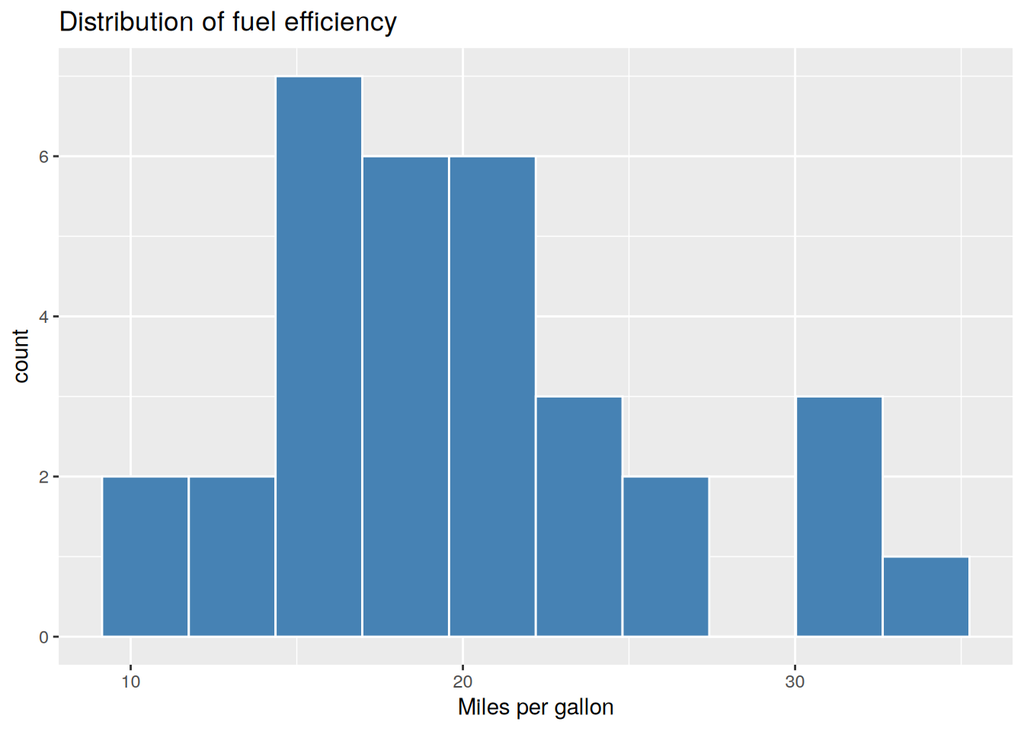

```r
ggplot(Data, aes(mpg)) +
  geom_histogram(bins = 10, fill = "steelblue", color = "white") +
  labs(title = "Distribution of fuel efficiency", x = "Miles per gallon")
```

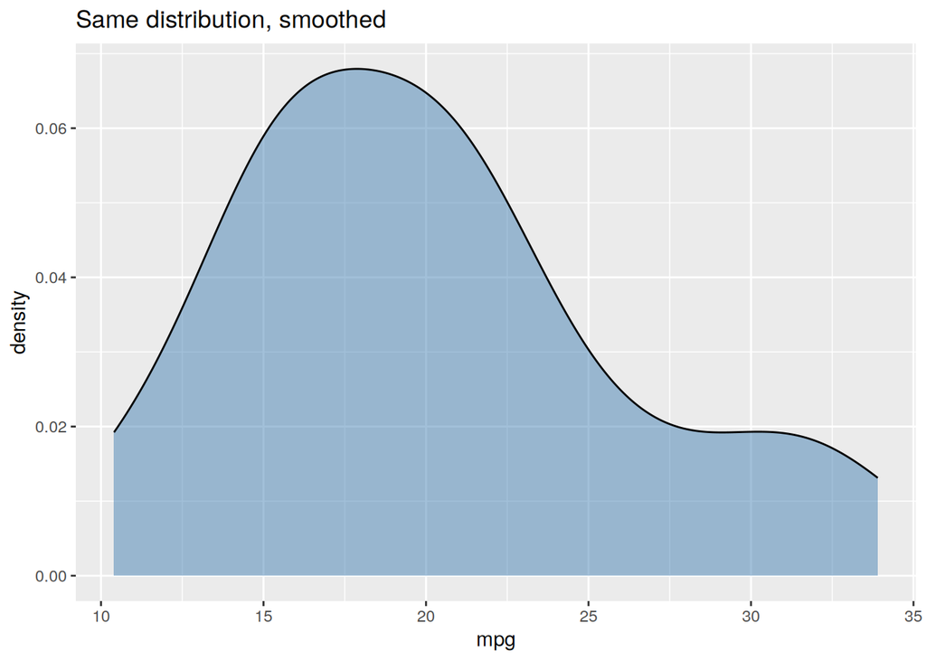

```r
ggplot(Data, aes(mpg)) +
  geom_density(fill = "steelblue", alpha = 0.5) +
  labs(title = "Same distribution, smoothed")
```

```r
f1 <- ggplot(Data, aes(mpg)) + geom_density()
```

## 2.1 Bin width matters — a lot

The single most important choice in a histogram is the **bin width**. Too few bins hides structure; too many bins shows noise. Same data, three different stories:

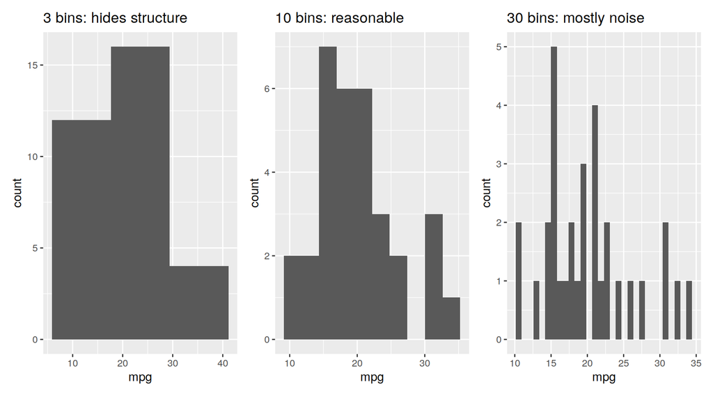

```r
p_wide  <- ggplot(Data, aes(mpg)) + geom_histogram(bins = 3)  + ggtitle("3 bins: hides structure")
p_ok    <- ggplot(Data, aes(mpg)) + geom_histogram(bins = 10) + ggtitle("10 bins: reasonable")
p_narrow<- ggplot(Data, aes(mpg)) + geom_histogram(bins = 30) + ggtitle("30 bins: mostly noise")

library(patchwork)
p_wide + p_ok + p_narrow
```

## 2.2 Distribution by group: boxplots

When you want a distribution **and** a categorical grouping at once, a boxplot (or violin plot) beats overlapping histograms:

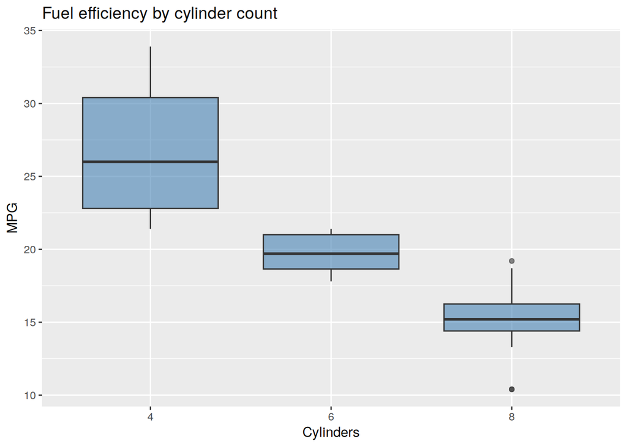

```r
ggplot(Data, aes(x = factor(cyl), y = mpg)) +
  geom_boxplot(fill = "steelblue", alpha = 0.6) +
  labs(x = "Cylinders", y = "MPG", title = "Fuel efficiency by cylinder count")
```

# 3 Relationships: scatter plots

Use a scatter plot to see the **relationship between two numeric variables**.

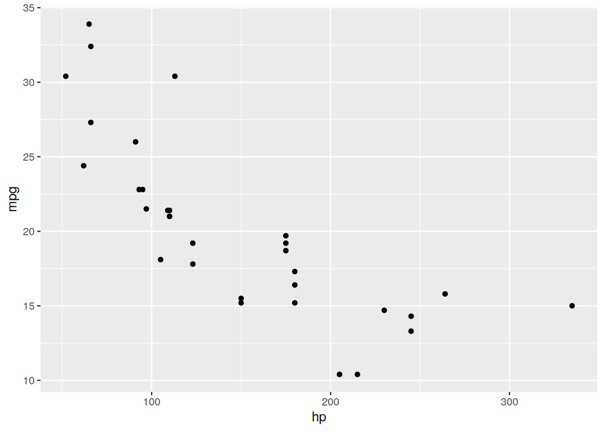

```r
f3 <- Data %>%
  ggplot(aes(x = hp, y = mpg)) +
  geom_point()
f3
```

Add a trend line to summarize the relationship:

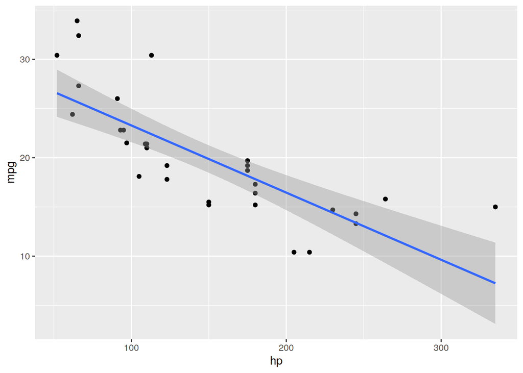

```r
f3 + geom_smooth(method = "lm")
```

## 3.1 Encoding a third variable

Color, size, or shape can add a third (or fourth) dimension to a scatter plot — but use this sparingly, or the plot becomes hard to read:

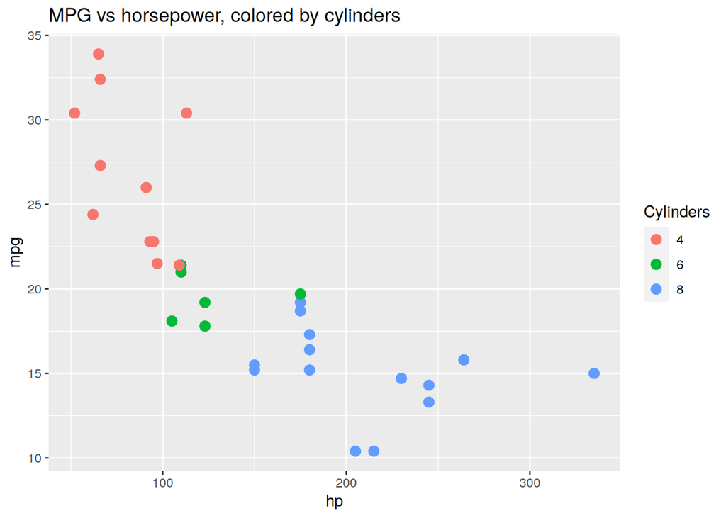

```r
Data %>%
  ggplot(aes(x = hp, y = mpg, color = factor(cyl))) +
  geom_point(size = 3) +
  labs(color = "Cylinders", title = "MPG vs horsepower, colored by cylinders")
```

**Correlation ≠ causation**

A downward trend between horsepower and MPG doesn’t prove horsepower *causes* lower fuel efficiency — both are driven by engine size and car weight. Always ask what else might explain the pattern before you tell a causal story.

## 3.2 A special case: line plots

When x represents an **order or sequence** (time, row number), a line plot connects the dots to emphasize that order:

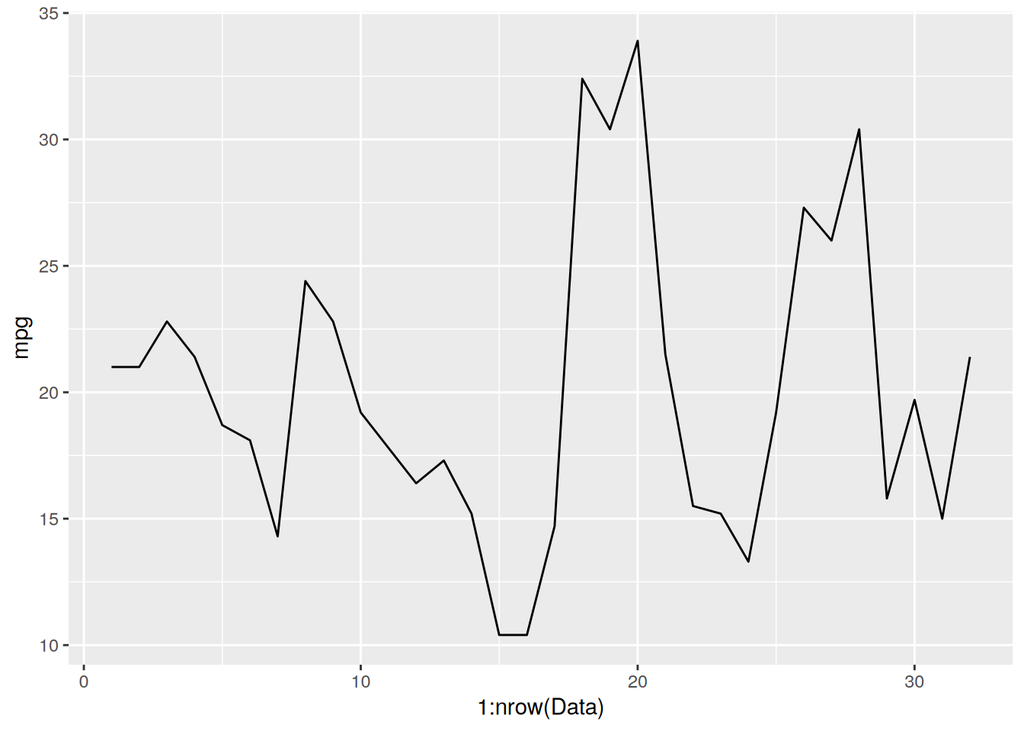

```r
f4 <- Data %>%
  ggplot(aes(x = 1:nrow(Data), y = mpg)) +
  geom_line()
f4
```

# 4 Making a plot good

## 4.1 Decorating a plot

The same plot, progressively polished:

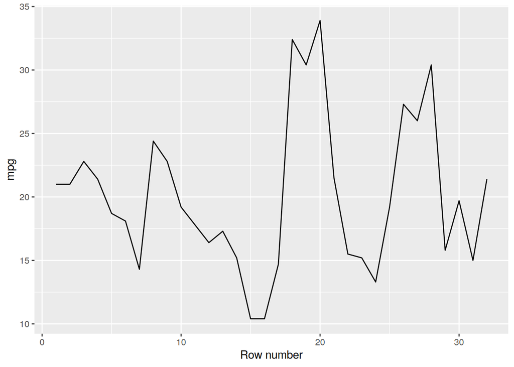

```r
f4 + xlab("Row number")
```

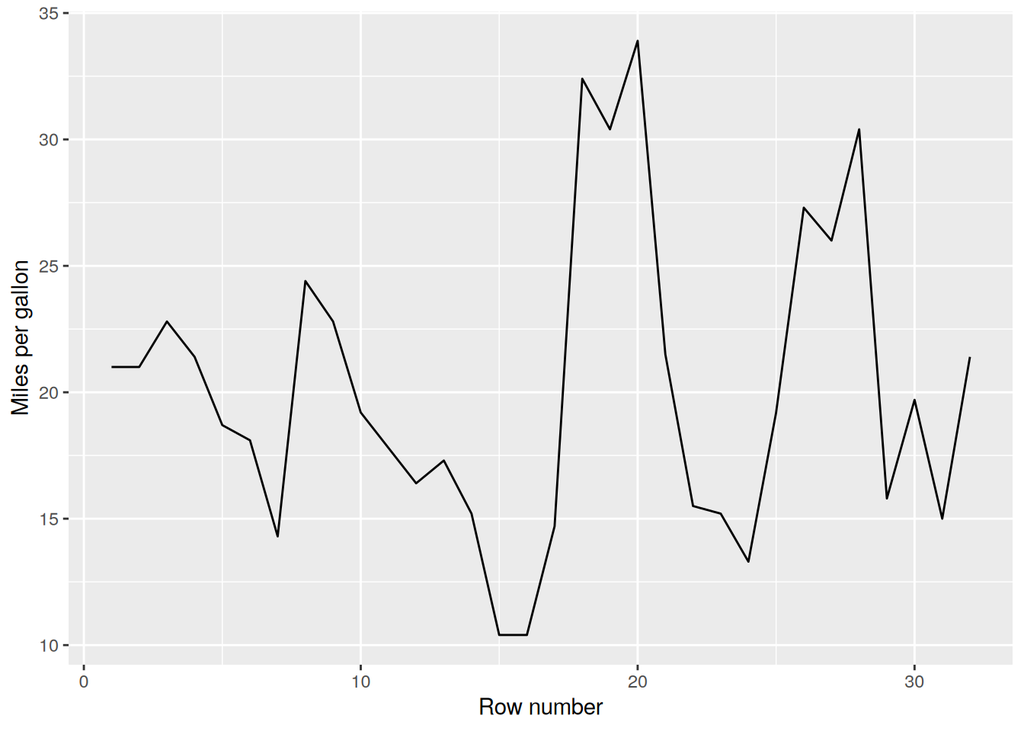

```r
f4 + xlab("Row number") + ylab("Miles per gallon")
```

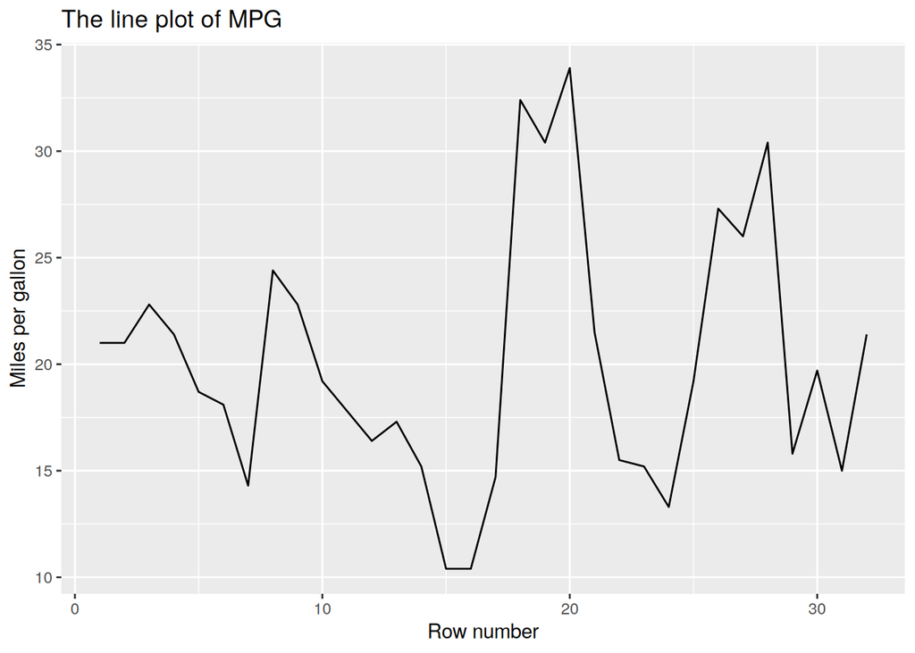

```r
f4 + xlab("Row number") + ylab("Miles per gallon") +
  ggtitle("The line plot of MPG")
```

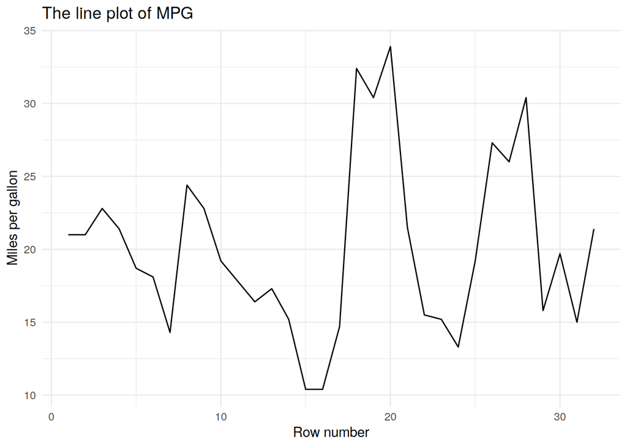

```r
f4 + xlab("Row number") + ylab("Miles per gallon") +
  ggtitle("The line plot of MPG") + theme_minimal()
```

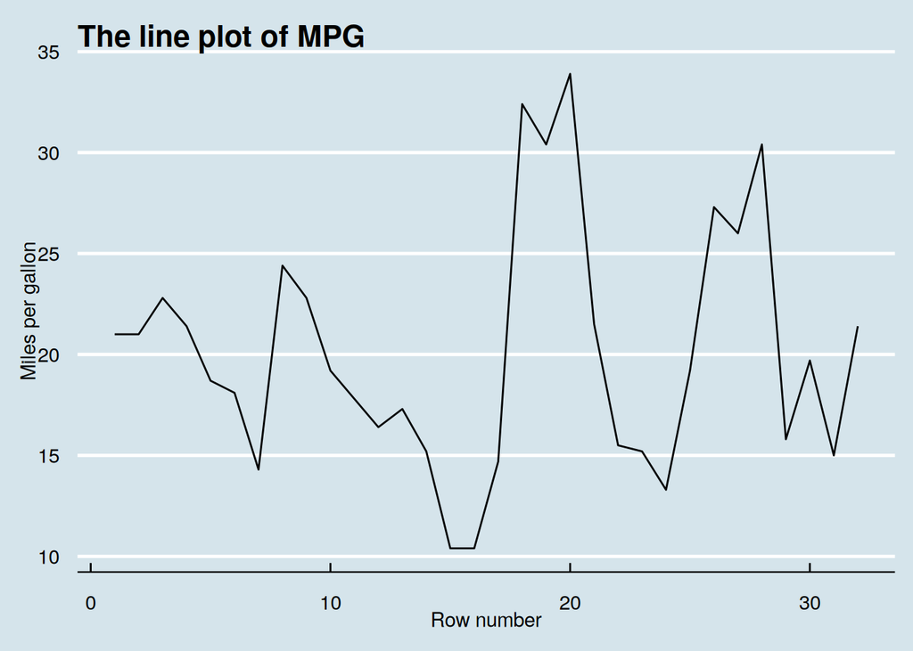

```r
f5 <- f4 + xlab("Row number") + ylab("Miles per gallon") +
  ggtitle("The line plot of MPG") + ggthemes::theme_economist()
f5
```

## 4.2 Principles of a good plot

1. **Match the geom to the variable type.** Categorical → bar. Numeric distribution → histogram/density/boxplot. Relationship → scatter. Order/time → line.
2. **Maximize the data-ink ratio** (Tufte). Every line, color, and gridline should earn its place. Delete anything that doesn’t help the reader.
3. **Be honest with scales.** Bar charts should start at zero. Don’t rescale an axis just to make a change look bigger or smaller than it is.
4. **Use color with a purpose**, not decoration — to group, to highlight, or to encode a variable. Prefer colorblind-safe palettes (`scale_color_viridis_d()`).
5. **Label like the reader knows nothing.** Axis titles, units, and a title that states the takeaway (not just the variable names) beat a legend the reader has to decode.
6. **One idea per plot.** If you need three sentences to explain what a plot shows, it’s probably two plots.

## 4.3 Interactive plots

`plotly::ggplotly()` turns any ggplot into an interactive plot (hover tooltips, zoom, pan) with almost no extra code:

```r
plotly::ggplotly(f3)
```

[interactive chart not shown]

```r
plotly::ggplotly(f5)
```

[interactive chart not shown]

Interactivity is great for **exploration** (letting a reader dig into the data themselves) but can be a distraction in a **static report** meant to make one clear point. Choose based on where the plot will live.

# 5 Spotting bad and misleading plots

Most misleading plots aren’t outright lying with fake numbers — they’re using **real data with a distorted visual encoding**. Below are six real charts that were actually published. For each one:

1. Look at the plot **before reading past it**.
2. Discuss: *What is this plot claiming? What would a quick glance make you believe?*
3. Then expand the “Reveal” box below it for the explanation and the correct way to draw it.

**A note on these images**

All six are hotlinked from the articles that reported on them, not republished by the original chart-maker — if a link ever breaks, the source article titles below will still find the story.

## 5.1 Example 1: a tax-rate bar chart

[figure not shown]

Fox News: top marginal tax rate if the Bush tax cuts expire

Source: aired on Fox News (2012); discussed in [FlowingData — “Fox News continues charting excellence”](https://flowingdata.com/2012/08/06/fox-news-continues-charting-excellence/)

**Discuss:** What two numbers is this chart comparing? Looking only at the bar heights, how much bigger does the right bar look than the left one?

**Reveal**

The bars show 35% and 39.6% — a real difference of 4.6 percentage points, about a 13% relative increase. But the y-axis starts at 34%, not 0%, so the taller bar looks roughly **5 times** the height of the shorter one. That’s Trick 1: **the truncated (non-zero) y-axis** — readers judge a bar chart by comparing bar *heights*, and height only reads proportionally when the axis starts at zero.

**Correct version**, drawn with the axis starting at 0 — same data, honest proportions:

[figure not shown]

FlowingData’s corrected version, axis starting at zero

## 5.2 Example 2: a 3D pie chart

[figure not shown]

A 3D pie chart example

Source: [Western Kentucky University Libraries — “Deceptive Charts” guide](https://libguides.wku.edu/data-vis/deceptive-charts)

**Discuss:** Which slice looks biggest to you? Now imagine this same data with the 3D effect removed — would your ranking change?

**Reveal**

The 3D perspective tilts the “plate” so slices in the front appear larger and closer than they really are, while slices angled toward the back are compressed — the visual size of a slice no longer matches its actual share of the data. Human eyes are already bad at comparing *areas and angles* (what a flat pie chart demands); 3D perspective makes it worse.

**Correct version:** drop the 3D effect entirely, and prefer a **sorted bar chart** over a pie whenever there are more than 3–4 categories — bars let readers compare length along one shared axis, which people read far more accurately than angles or 3D volumes.

## 5.3 Example 3: two lines, two axes

[figure not shown]

A dual-axis chart example

Source: [Western Kentucky University Libraries — “Deceptive Charts” guide](https://libguides.wku.edu/data-vis/deceptive-charts)

**Discuss:** Do the two lines look related? What would you conclude about how these two variables affect each other?

**Reveal**

Each line has its **own independently-scaled y-axis**. Because the two scales are chosen separately (not derived from the data), the lines can be stretched or shifted until they visually overlap — regardless of whether the underlying variables have any real relationship. This is the “ice cream sales vs. crime rate” trick: both might just be responding to a third, unmentioned factor (e.g., warm weather) rather than to each other.

**Correct version:** either plot the two series on **separate stacked panels** with their own clearly-labeled axes (no forced overlap), or convert both to a common, meaningful scale (e.g., % change from baseline) *only* if that comparison is actually meaningful for the question being asked.

## 5.4 Example 4: gun deaths over time

[figure not shown]

Reuters’ chart of gun deaths in Florida

Source: aired via Reuters (2014); discussed in [Sociological Images — “How to Lie with Statistics: Stand Your Ground and Gun Deaths”](https://thesocietypages.org/socimages/2014/12/28/how-to-lie-with-statistics-stand-your-ground-and-gun-deaths/)

**Discuss:** Does the trend line go up or down? What does that make you think happened to gun deaths in Florida over this period?

**Reveal**

Look closely at the y-axis labels: they **increase going downward**. The axis has been flipped upside down, so a trend line that is actually *rising* (gun deaths went up) visually reads as *falling*. This is one of the more brazen tricks because it doesn’t touch the data or the scale range at all — it just reverses which direction is “up.”

**Correct version:** flip the axis back to the normal orientation (values increasing upward). No other change to the data is needed — the honest version is the same chart with the axis un-flipped.

## 5.5 Example 5: a map of reported cases

[figure not shown]

A choropleth map with a reversed color scale

Source: discussed in [wpDataTables — “Misleading Data Visualization Examples”](https://wpdatatables.com/misleading-data-visualization-examples/)

**Discuss:** Which regions look like they’re doing “worst” at a glance? What convention are you assuming when you read a map like this?

**Reveal**

Most readers assume **darker = more** on a map like this (more cases, more severity). This map reverses that convention — darker regions actually have *fewer* reported cases, and lighter regions have *more*. Nothing about the data is wrong; the color mapping is just inverted from what readers instinctively expect, so most people misread the map at a glance.

**Correct version:** use a sequential color scale where the darkest shade maps to the *highest* value (e.g., `scale_fill_viridis_c()` in `ggplot2`), matching the convention readers already carry into the chart.

## 5.6 Example 6: comparing two circle sizes

[figure not shown]

Circles sized by diameter instead of area

Source: originally from Visual Capitalist’s startup-valuation infographic; discussed in [Cool Infographics — “False Visualizations: Getting Circles Sizes Wrong”](https://coolinfographics.com/blog/2021/12/15/false-visualizations-getting-circles-sizes-wrong)

**Discuss:** One company is valued at exactly 2x the other. Looking only at the circles, how many times bigger does the larger one appear?

**Reveal**

The larger circle’s **diameter** was set to exactly 2x the smaller one’s — but viewers perceive a circle by its *area*, and area grows with the *square* of the radius/diameter. A 2x diameter difference reads as roughly a **4x** difference in visual size, exaggerating the real gap.

**Correct version:** scale circles by **area**, not diameter — so a value that’s 2x larger gets a diameter of only √2 (≈1.41x), which then *displays* as correctly 2x the area. (`ggplot2`’s `scale_size()` does this correctly by default; the mistake usually comes from manually setting diameter/radius.)

**Homework**

`homework-bad-plots.qmd` gives you clean, made-up data for four of the tricks above (truncated axis, dual axes, wrong chart type, radius vs. area) and asks you to build both a good and a deliberately bad plot yourself — no starter plotting code provided.

**In-class exercise**

In pairs, find one more misleading chart currently circulating online (news, social media, a company report). Identify which trick above it uses, and sketch how you’d redraw it honestly.

# 6 Wrap-up

- Variable type determines geom: categorical → bar, numeric distribution → histogram/density/boxplot, relationship → scatter, order/time → line.
- A good plot is honest (scales, framing) and stripped of anything that doesn’t serve the reader.
- Misleading plots almost always come from **one of a handful of tricks**: truncated axes, dual axes, wrong chart type, distorted size/color encoding, or clutter. Once you know the tricks, they jump out immediately.
- Next: combining several plots into one **Quarto dashboard** (see `dashboard-example.qmd`).

**Homework:** `homework-bad-plots.qmd` — build a good and a misleading plot for each of the four tricks above. Optional extra: also find one bad plot “in the wild” and rebuild a corrected version, with 2–3 sentences on what you changed and why.